# Definisi Queues

Queues atau antrian merupakan struktur data dimana penambahan data baru dan penghapusan data berada di ujung yang berbeda. Hal ini berbeda dengan stacks, dimana penambahan data baru dan penghapusan data, dilakukan pada ujung yang sama. Pada Queues, seperti halnya antrian, penambahan data baru dilakukan di suatu ujung atau yang dikenal dengan nama rear, dan penghapusan data dilakukan pada ujung yang dikenal dengan nama front, seperti yang terlihat pada Gambar 1 berikut :

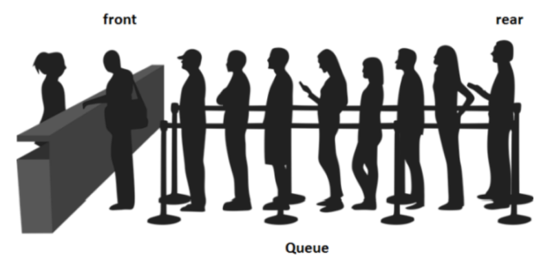

Jika konsep penambahan atau penghapusan data pada stacks dikenal dengan nama LIFO (Last In First Out), maka pada Queues menggunakan konsep FIFO (First In First Out)

# Operasi pada Queues

Terdapat beberapa operasi dasar pada struktur data Queues ini, antara lain :

- queue (), inisialisasi struktur data queue kosong
- enqueue (data), penambahan *data* baru pada queue
- dequeue (), penghapusan data
- isEmpty(), pengecekan apakah queue dalam keadaan kosong
- size (), informasi jumlah data yang terdapat pada queue Ilustrasi penambahan dan penghapusan data dapat dilihat pada Gambar 2 dan Gambar 3 berikut :

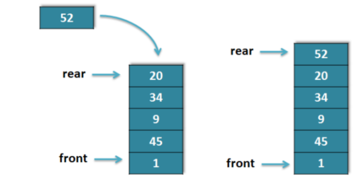

Gambar 2. Operasi enqueue pada queues

[figure not shown]

Gambar 3. Operasi dequeue pada queues

```python
def createQueue():
    q = []
    return q

def enqueue(q, data):
    q.insert(0, data)
    return q

def dequeue(q):
    data = q.pop()
    return data

def isEmpty(q):
    return (q == [])

def size(q):
    return len(q)
```

```python
q = createQueue()

enqueue(q, 'matematika')
enqueue(q, 'struktur data')
enqueue(q, 'bahasa inggris')
enqueue(q, 'pemrograman web')

print(q)
```

```
['pemrograman web', 'bahasa inggris', 'struktur data', 'matematika']
```

```python
temp=dequeue(q)
print(q)
print(temp)
```

```
['pemrograman web', 'bahasa inggris', 'struktur data']
matematika
```

```python
enqueue(q,dequeue(q))
print(q)
```

```
['struktur data', 'pemrograman web', 'bahasa inggris']
```

```python
a=dequeue(q)
print(a,q)
```

```
bahasa inggris ['struktur data', 'pemrograman web']
```

```python
def ularNaga(nama, hitungan):
    gameQueue = createQueue()

    for namaAnak in nama:
        enqueue(gameQueue, namaAnak)

    print('Peserta Permainan =', gameQueue)

    while size(gameQueue) > 1:

        for i in range(hitungan):
            enqueue(gameQueue, dequeue(gameQueue))
            print('hitungan ke-', i, '=', gameQueue)

        dequeue(gameQueue)
        print('Peserta Permainan =', gameQueue)

    return dequeue(gameQueue)
```

```python
ularNaga(['andi','rita','sari','anton'],2)
```

```
Peserta Permainan = ['anton', 'sari', 'rita', 'andi']
hitungan ke- 0 = ['andi', 'anton', 'sari', 'rita']
hitungan ke- 1 = ['rita', 'andi', 'anton', 'sari']
Peserta Permainan = ['rita', 'andi', 'anton']
hitungan ke- 0 = ['anton', 'rita', 'andi']
hitungan ke- 1 = ['andi', 'anton', 'rita']
Peserta Permainan = ['andi', 'anton']
hitungan ke- 0 = ['anton', 'andi']
hitungan ke- 1 = ['andi', 'anton']
Peserta Permainan = ['andi']
```

```
'andi'
```